# Rock Paper Scissors

Played Rock Paper Scissors at Evelyn’s house

- I beat five or seven players in a row using dad’s algorithm
- Is dad’s algorithm actually better than randomly picking r p s?

```r
# library(tidyverse)
# looks like readr is broken at the moment
# see https://community.rstudio.com/t/issue-with-installing-the-drc-package/18701/3
```

```r
library(tidyr)
library(dplyr)
library(magrittr)
library(ggplot2)
```

# 1

Rules for our simulation

- Alice is our stand-in: every win, she gets a point, every tie she gets no points, and every loss she looses a point
- Bob is our opponent

Some simulation parameters and helper functions

```r
nm <- c("rock", "paper", "scissors")
rps <- factor(nm, levels = nm)
n.games <- 60000
```

```r
# helper function, given vectors of alice and bob results, column binds and calculating the score of each game
calc.wins <- function (alice, bob) {
    games <- bind_cols(list(alice, bob)) %>%
        rename(alice = V1, bob = V2) %>%
        mutate(score = case_when(
            alice == "rock" & bob == "rock" ~ 0
            , alice == "paper" & bob == "rock" ~ 1
            , alice == "scissors" & bob == "rock" ~ -1
            , alice == "rock" & bob == "paper" ~ -1
            , alice == "paper" & bob == "paper" ~ 0
            , alice == "scissors" & bob == "paper" ~ 1
            , alice == "rock" & bob == "scissors" ~ 1
            , alice == "paper" & bob == "scissors" ~ -1
            , alice == "scissors" & bob == "scissors" ~ 0
            , TRUE ~ 0
        ))
    return(games)
}
```

# 2

In a set of purely random games, we would not expect a clear winner or looser, e.g. uniform distribution of -1, 0, 1

so we simulate the games

```r
alice <- sample(rps, n.games, replace = TRUE)
bob <- sample(rps, n.games, replace = TRUE)
games <- calc.wins(alice, bob)
```

So let’s see what the distribution of the scores were from the simulation.

```r
games %>% count(score)
```

| score | n |
| --- | --- |
| -1 | 20255 |
| 0 | 19879 |
| 1 | 19866 |

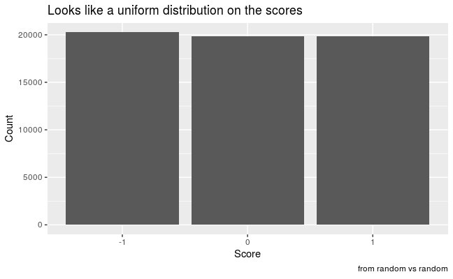

```r
games %>%
    ggplot(aes(x = factor(score))) +
    geom_bar() +
    labs(title = "Looks like a uniform distribution on the scores", x = "Score", y = "Count", caption = "from random vs random")
```

Well certainly looks uniform, but how to be more precise about it? Let’s use a chi-squared test.

In a chi-squared test, we’re testing the chances, under the null hypothesis that we should have had a uniform distribution, that we’d see this distribution by random chance

```r
games %>%
    count(score) %>%
    spread(key = score, value = n, fill = 0) %>%
    chisq.test()
```

```
    Chi-squared test for given probabilities

data:  .
X-squared = 4.8811, df = 2, p-value = 0.08711
```

… what if we did this using resampling technique? Actually this breaks RStudio cloud

```r
# games %>%
#     count(score) %>%
#     spread(key = score, value = n, fill = 0) %>%
#     chisq.test(simulate.p.value = TRUE)
```

… what if we did this test by hand?

Well the Pearson residuals for each cell is: (actual - expected) / sqrt(expected)

```r
games %>%
    count(score) %>%
    spread(key = score, value = n, fill = 0) %>%
    mutate(
        `-1` = (`-1` - n.games/3) / sqrt(n.games/3)
        , `0` = (`0` - n.games/3) / sqrt(n.games/3)
        , `1` = (`1` - n.games/3) / sqrt(n.games/3))
```

| -1 | 0 | 1 |
| --- | --- | --- |
| 1.803122 | -0.8555992 | -0.9475231 |

```r
games %>%
    count(score) %>%
    spread(key = score, value = n, fill = 0) %>%
    mutate(
        `-1` = (`-1` - n.games/3) / sqrt(n.games/3)
        , `0` = (`0` - n.games/3) / sqrt(n.games/3)
        , `1` = (`1` - n.games/3) / sqrt(n.games/3)) %>%
    gather(key = score, value = residuals) %>%
    summarize(c = sum(residuals))
```

| c |
| --- |
| 0 |

# 3

But what if Alice uses the following algorithm?

- in first game, randomly pick